# Heart Attack Prediction

Hendi Kurniawan, Prajudi William Chrisdeardo (Willy)

4/7/2021

# Description

The topic of the dataset I chose was about heart attack prediction. Heart disease is among the top 10 deadliest diseases in the world, according to the WHO. The method I use for topics is to use classification. To download the dataset, please click [here.](https://www.kaggle.com/rashikrahmanpritom/heart-attack-analysis-prediction-dataset)

The report is structured as follows:  
1. Data Extraction  
2. Exploratory Data Analysis (EDA)  
3. Data Preparation  
4. Modeling  
5. Evaluation  
6. Recommendation

# 1. Data Extraction

Import necessary libraries.

```r
rm(list = ls())
```

# 1.1. Read Data

Create and read data frames that we create.

```r
# Read data
heart_df <- read.csv("C:/Users/lenovo/Documents/tugasprojek/data/heart.csv")
```

# 1.2. Structure of Data Frame

Create a data frame structure.

```r
# Structure of Data Frame
str (heart_df)
```

```
## 'data.frame':    303 obs. of  14 variables:
##  $ age     : int  63 37 41 56 57 57 56 44 52 57 ...
##  $ sex     : int  1 1 0 1 0 1 0 1 1 1 ...
##  $ cp      : int  3 2 1 1 0 0 1 1 2 2 ...
##  $ trtbps  : int  145 130 130 120 120 140 140 120 172 150 ...
##  $ chol    : int  233 250 204 236 354 192 294 263 199 168 ...
##  $ fbs     : int  1 0 0 0 0 0 0 0 1 0 ...
##  $ restecg : int  0 1 0 1 1 1 0 1 1 1 ...
##  $ thalachh: int  150 187 172 178 163 148 153 173 162 174 ...
##  $ exng    : int  0 0 0 0 1 0 0 0 0 0 ...
##  $ oldpeak : num  2.3 3.5 1.4 0.8 0.6 0.4 1.3 0 0.5 1.6 ...
##  $ slp     : int  0 0 2 2 2 1 1 2 2 2 ...
##  $ caa     : int  0 0 0 0 0 0 0 0 0 0 ...
##  $ thall   : int  1 2 2 2 2 1 2 3 3 2 ...
##  $ output  : int  1 1 1 1 1 1 1 1 1 1 ...
```

# 1.3. Data Dimension

Create dimensional data.

```r
# Data Dimension
d <- dim(heart_df)
m <- d[1] # m : number of rows
n <- d[2] # n : number of columns
```

Make summaries.

```r
# Statistical Summary
summary(heart_df)
```

```
##       age             sex               cp            trtbps
##  Min.   :29.00   Min.   :0.0000   Min.   :0.000   Min.   : 94.0
##  1st Qu.:47.50   1st Qu.:0.0000   1st Qu.:0.000   1st Qu.:120.0
##  Median :55.00   Median :1.0000   Median :1.000   Median :130.0
##  Mean   :54.37   Mean   :0.6832   Mean   :0.967   Mean   :131.6
##  3rd Qu.:61.00   3rd Qu.:1.0000   3rd Qu.:2.000   3rd Qu.:140.0
##  Max.   :77.00   Max.   :1.0000   Max.   :3.000   Max.   :200.0
##       chol            fbs            restecg          thalachh
##  Min.   :126.0   Min.   :0.0000   Min.   :0.0000   Min.   : 71.0
##  1st Qu.:211.0   1st Qu.:0.0000   1st Qu.:0.0000   1st Qu.:133.5
##  Median :240.0   Median :0.0000   Median :1.0000   Median :153.0
##  Mean   :246.3   Mean   :0.1485   Mean   :0.5281   Mean   :149.6
##  3rd Qu.:274.5   3rd Qu.:0.0000   3rd Qu.:1.0000   3rd Qu.:166.0
##  Max.   :564.0   Max.   :1.0000   Max.   :2.0000   Max.   :202.0
##       exng           oldpeak          slp             caa
##  Min.   :0.0000   Min.   :0.00   Min.   :0.000   Min.   :0.0000
##  1st Qu.:0.0000   1st Qu.:0.00   1st Qu.:1.000   1st Qu.:0.0000
##  Median :0.0000   Median :0.80   Median :1.000   Median :0.0000
##  Mean   :0.3267   Mean   :1.04   Mean   :1.399   Mean   :0.7294
##  3rd Qu.:1.0000   3rd Qu.:1.60   3rd Qu.:2.000   3rd Qu.:1.0000
##  Max.   :1.0000   Max.   :6.20   Max.   :2.000   Max.   :4.0000
##      thall           output
##  Min.   :0.000   Min.   :0.0000
##  1st Qu.:2.000   1st Qu.:0.0000
##  Median :2.000   Median :1.0000
##  Mean   :2.314   Mean   :0.5446
##  3rd Qu.:3.000   3rd Qu.:1.0000
##  Max.   :3.000   Max.   :1.0000
```

# 2. Exploratory Data Analysis (EDA)

Installing load libraries.

```r
library (ggplot2)
```

Turns certain variables into factors.

```r
# Change Variable Sex, cp, fbs, restecg, exng, slp, caa, thall and output to factor

heart_df$sex <-factor(heart_df$sex,
                         levels = c(1,0),
                         labels = c("Male","Female"))

heart_df$cp <-factor(heart_df$cp,
                      levels = c(1,2,3,0),
                      labels = c("Typical","atypical",
                                 "non anginal", "asymptomatic"))

heart_df$fbs <-factor(heart_df$fbs,
                      levels = c(1,0),
                      labels = c(">120 mg/dl","< 120 mg/dl"))

heart_df$restecg <-factor(heart_df$restecg,
                      levels = c(0,1,2),
                      labels = c("hypertrophy","ST-T Wave Abnormality", "Normal"))

heart_df$exng <-factor(heart_df$exng,
                          levels = c(0,1),
                          labels = c("Yes","No"))

heart_df$slp <-factor(heart_df$slp,
                       levels = c(0,1,2),
                       labels = c("downsloping","flat", "upsloping"))

heart_df$caa <-factor(heart_df$caa,
                      levels = c(0,1,2,3),
                      labels = c("0","1","2","3"))

heart_df$thall <-factor(heart_df$thall,
                      levels = c(1,2,3),
                      labels = c("fixed defect","normal","reversable defect"))

heart_df$output <-factor(heart_df$output,
                         levels = c(1,0),
                         labels = c("More","Less"))
```

# 2.1. Univariate Analysis

This part is making Univariate.

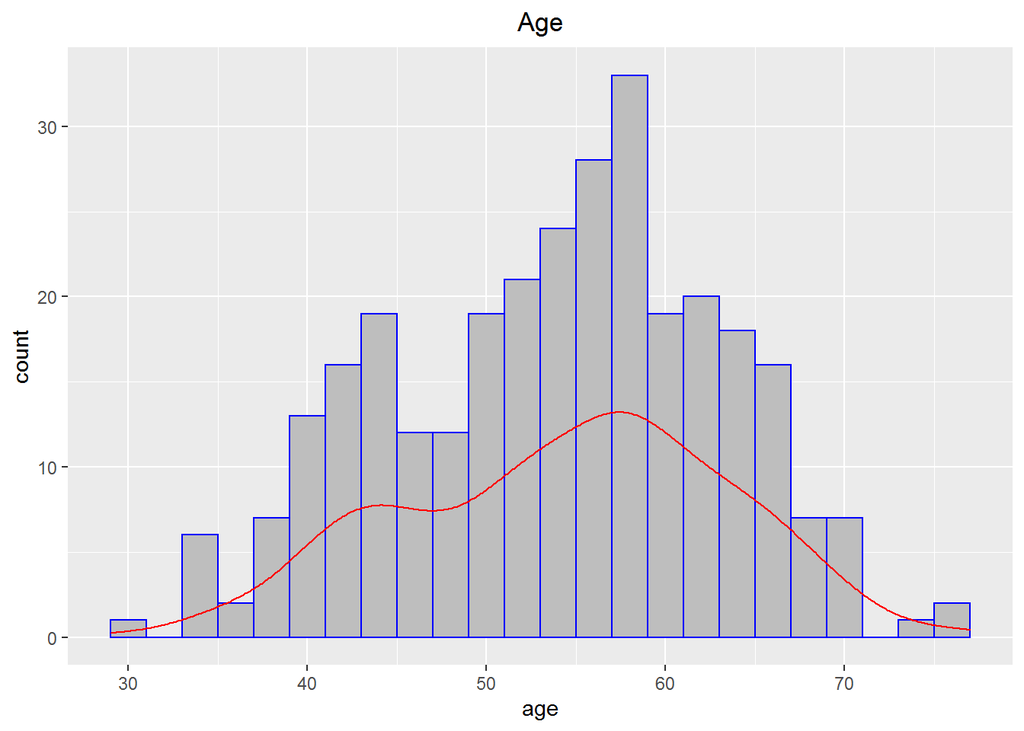

```r
ggplot(heart_df, aes(x=age, y=..count..)) +
  geom_histogram(binwidth = 2,
                 fill = "grey",
                 color = "BLUE") +
  geom_density(color = "Red") +
  ggtitle("Age") +
  theme(plot.title = element_text(hjust = 0.5))
```

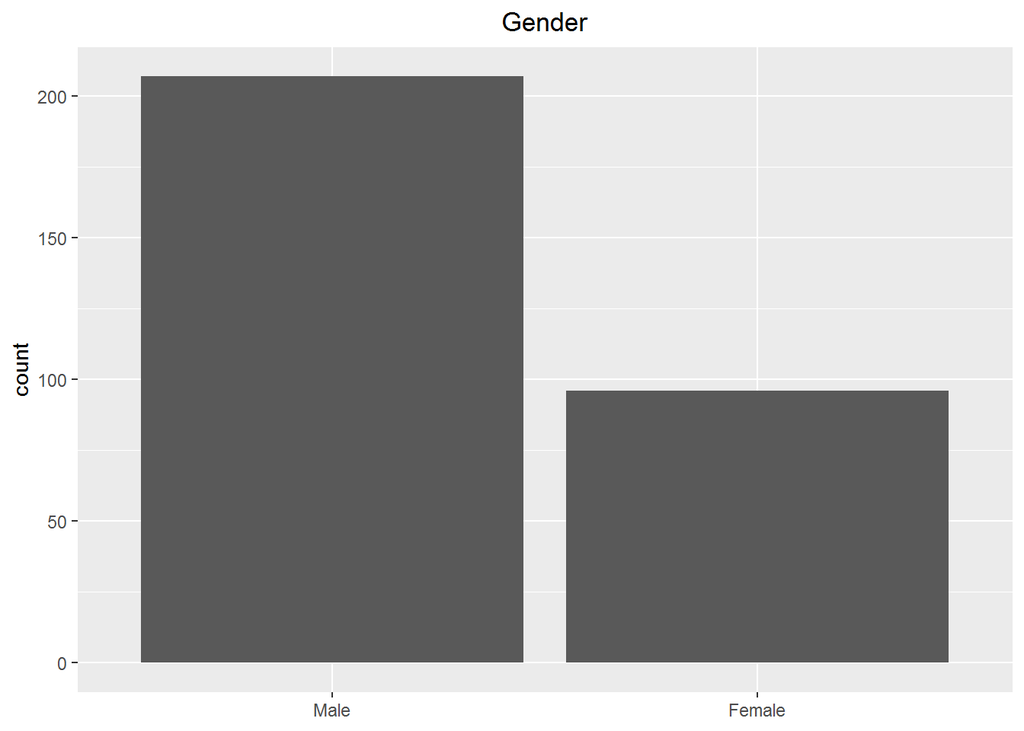

```r
plottingbar = function(x_column, label){
  ggplot(heart_df, aes(x = x_column)) +
    geom_bar()+
    labs(x = NULL)  +
    ggtitle(paste (label))+
    theme(plot.title = element_text(hjust = 0.5))
}

plottingbar(heart_df$sex, "Gender")
```

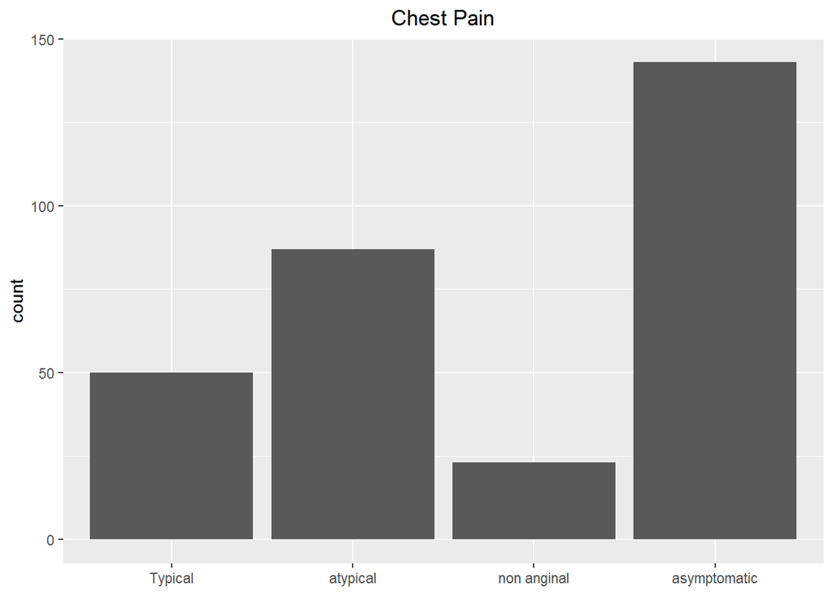

```r
plottingbar(heart_df$cp, "Chest Pain")
```

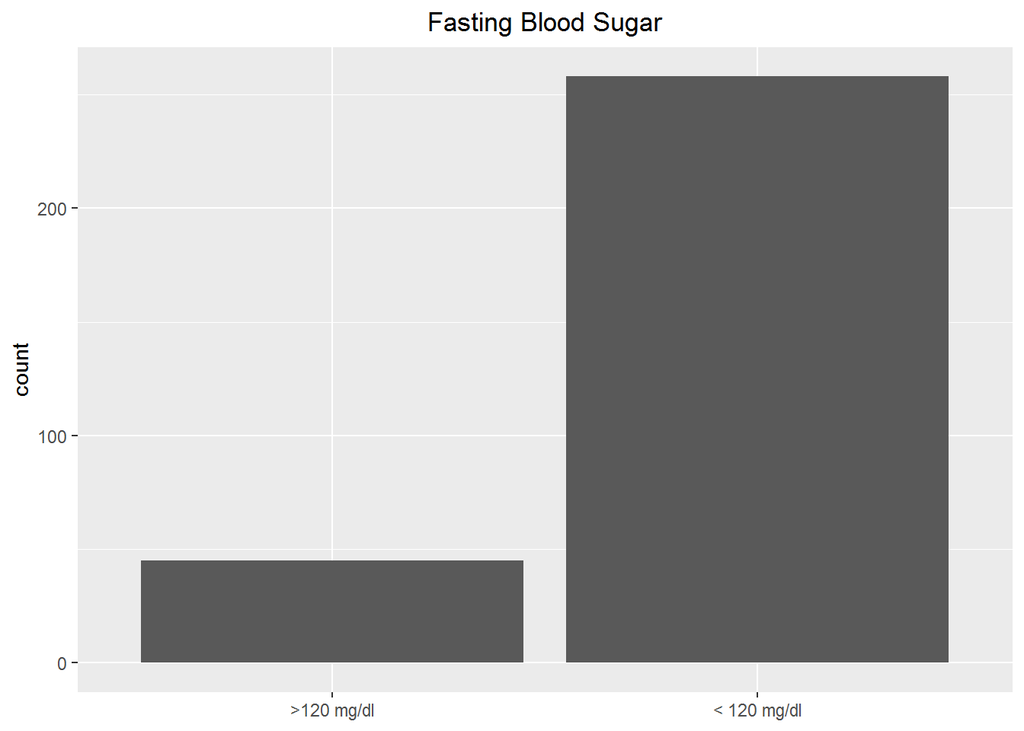

```r
plottingbar(heart_df$fbs, "Fasting Blood Sugar")
```

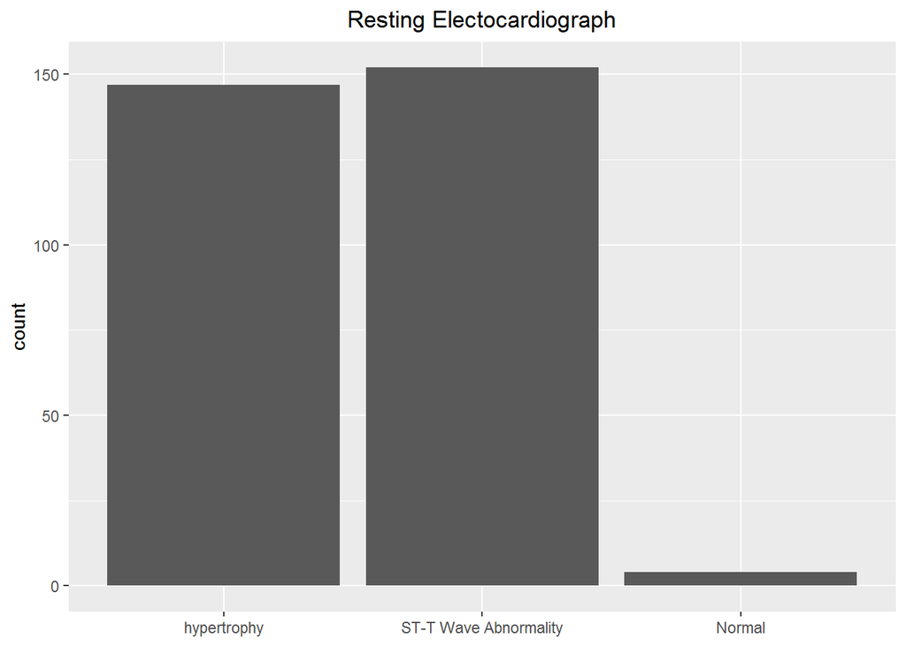

```r
plottingbar(heart_df$restecg, "Resting Electocardiograph")
```

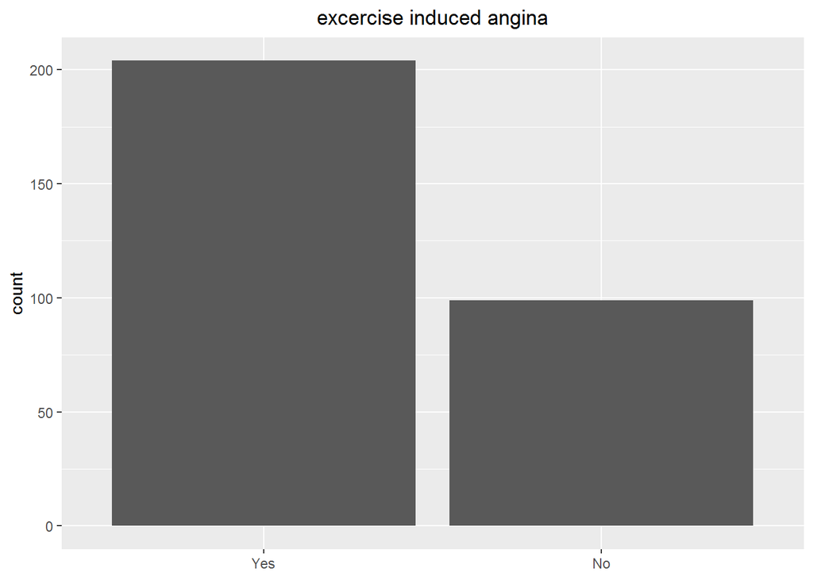

```r
plottingbar(heart_df$exng, "excercise induced angina")
```

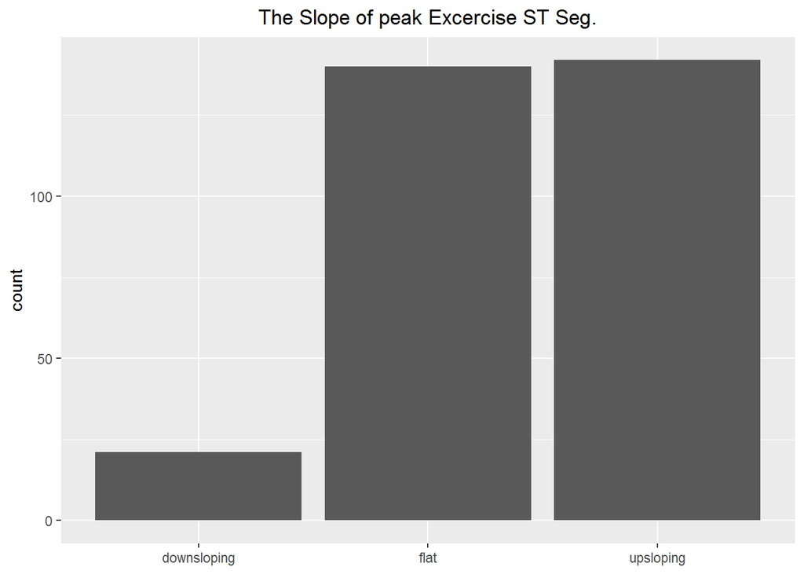

```r
plottingbar(heart_df$slp, "The Slope of peak Excercise ST Seg.")
```

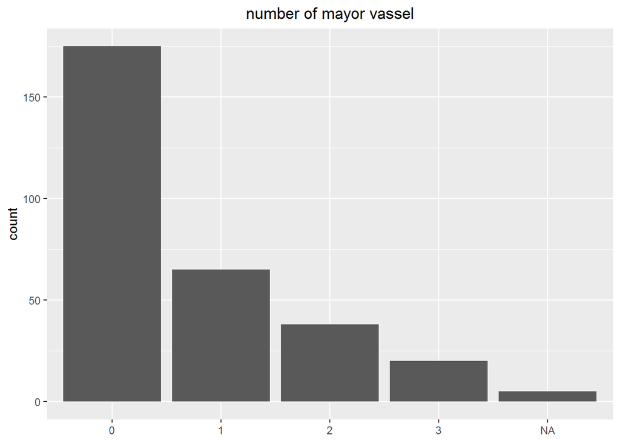

```r
plottingbar(heart_df$caa, "number of mayor vassel")
```

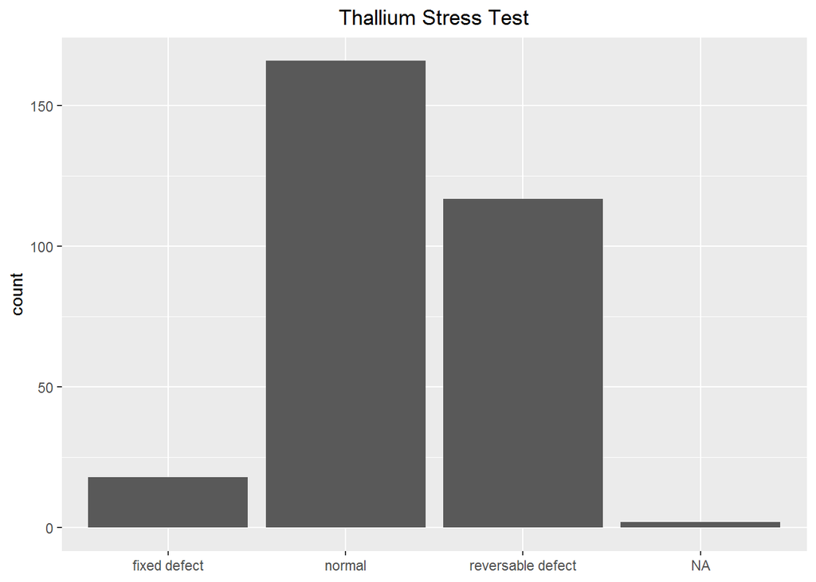

```r
plottingbar(heart_df$thall, "Thallium Stress Test")
```

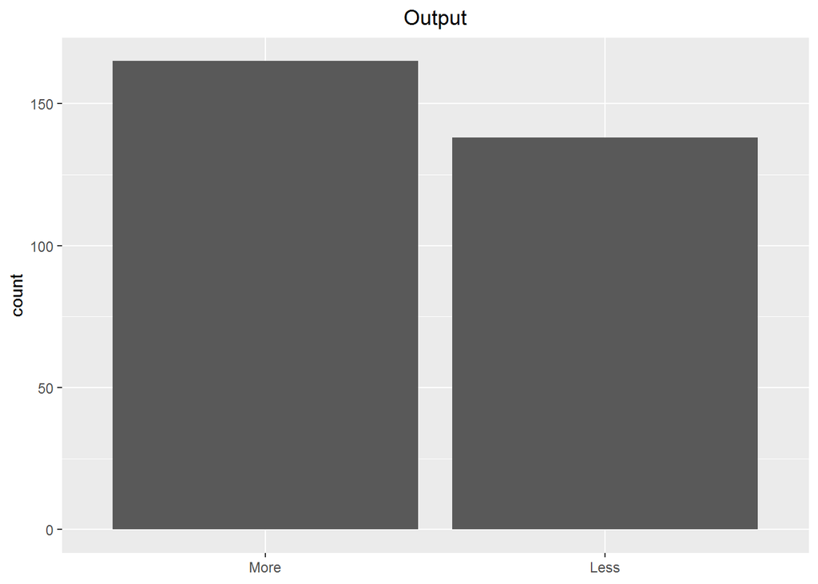

```r
plottingbar(heart_df$output, "Output")
```

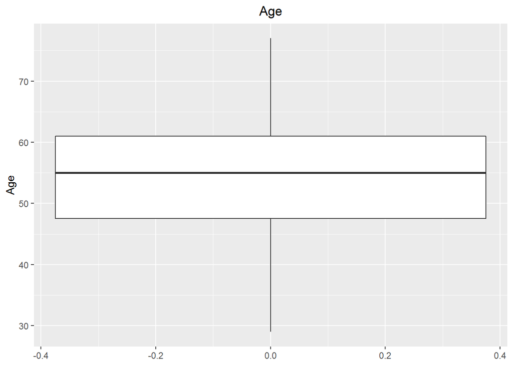

```r
plottingbp = function(y_row, label, unit){
  ggplot(heart_df, aes(y = y_row))+
    geom_boxplot()+
    labs (y = paste(unit))+
    ggtitle (paste(label))+
    theme(plot.title = element_text(hjust = 0.5))
}

plottingbp(heart_df$age, "Age", "Age")
```

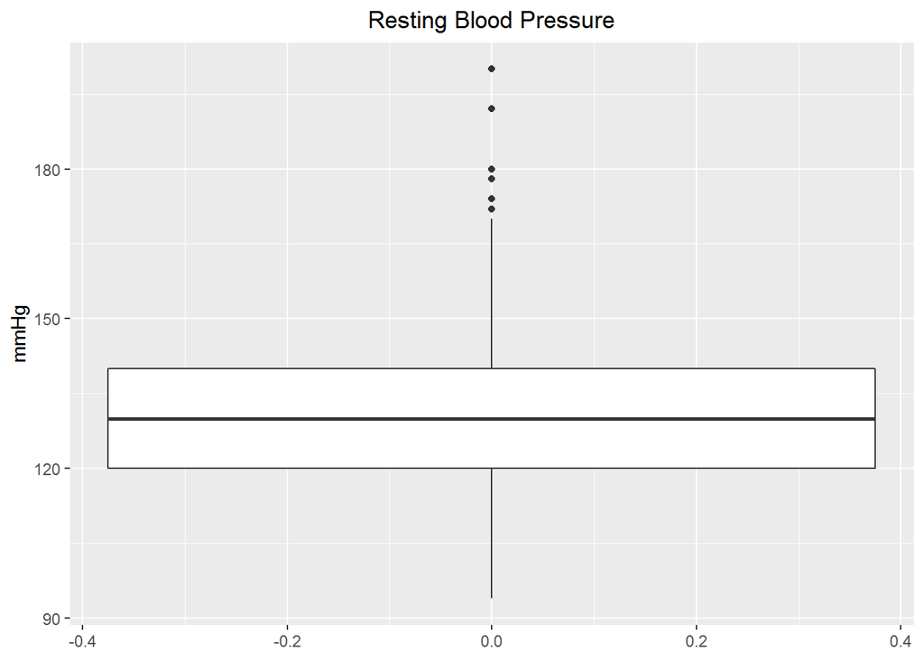

```r
plottingbp(heart_df$trtbps, "Resting Blood Pressure", "mmHg")
```

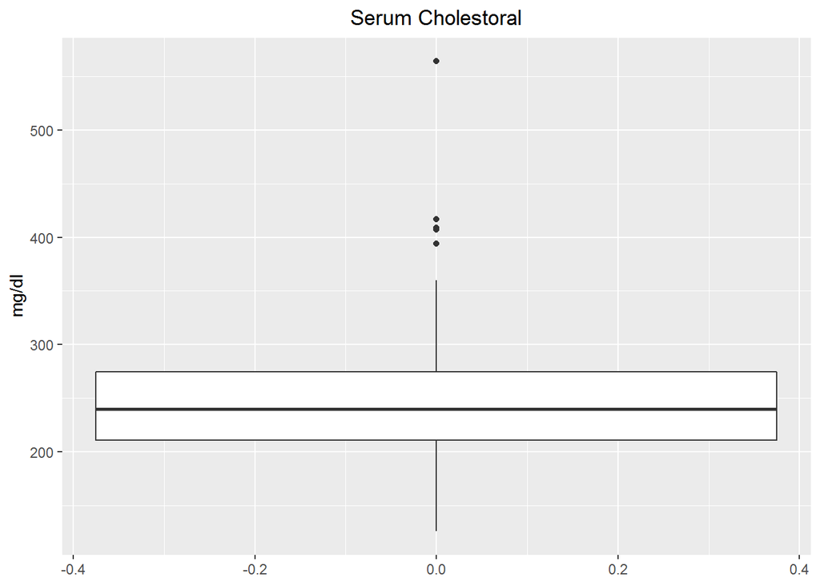

```r
plottingbp(heart_df$chol, "Serum Cholestoral", "mg/dl")
```

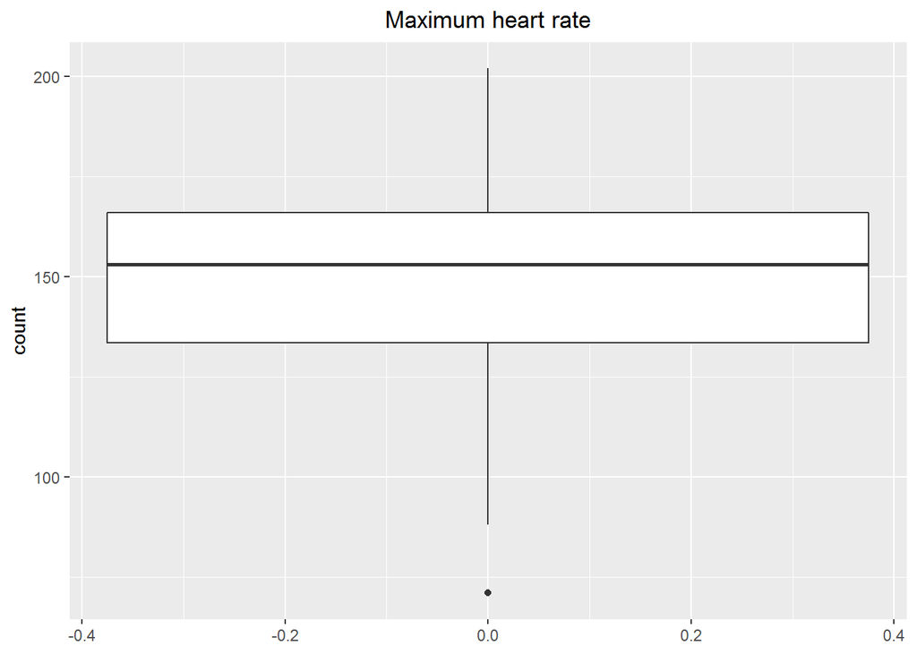

```r
plottingbp(heart_df$thalachh, "Maximum heart rate", "count")
```

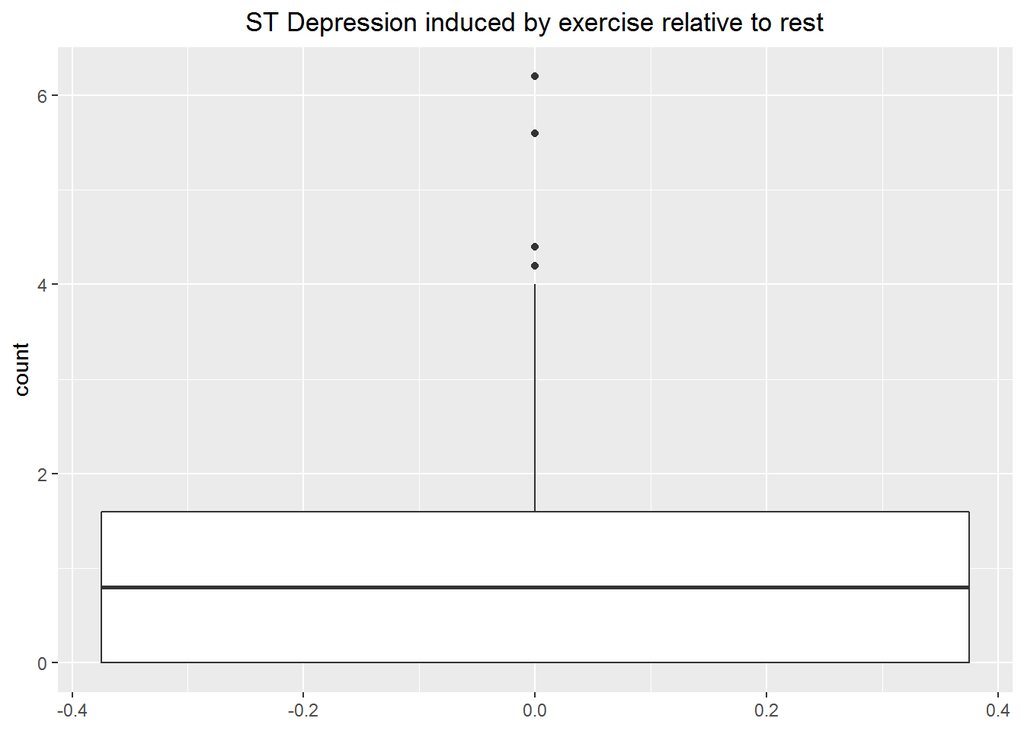

```r
plottingbp(heart_df$oldpeak, "ST Depression induced by exercise relative to rest", "count")
```

# 2.2. Bivariate Analysis

This part is making Bivariate.

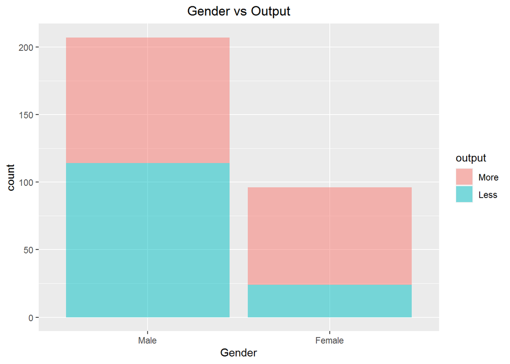

```r
# Factor Variable
plotting1 = function(x_column, label){
  ggplot(heart_df, aes(x = x_column, fill=output))+
    geom_bar(alpha = 0.5)+
    labs(title = paste(label, "vs Output"),
         x = label)+
    theme (plot.title = element_text(hjust = 0.5))
}

plotting1(heart_df$sex, "Gender")
```

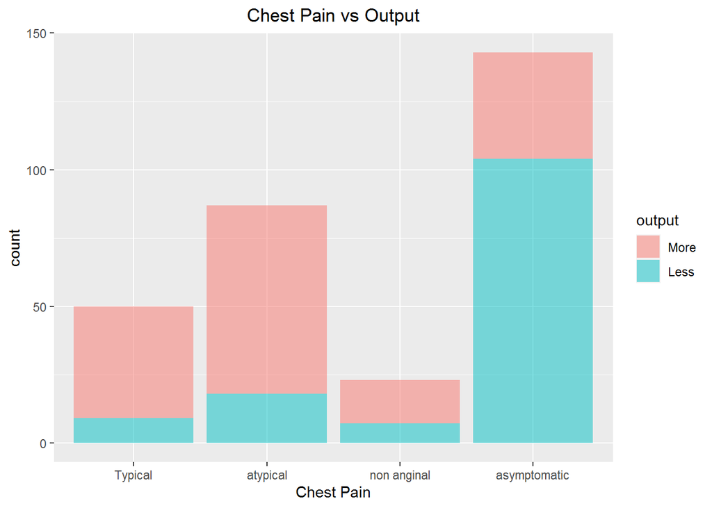

```r
plotting1(heart_df$cp, "Chest Pain")
```

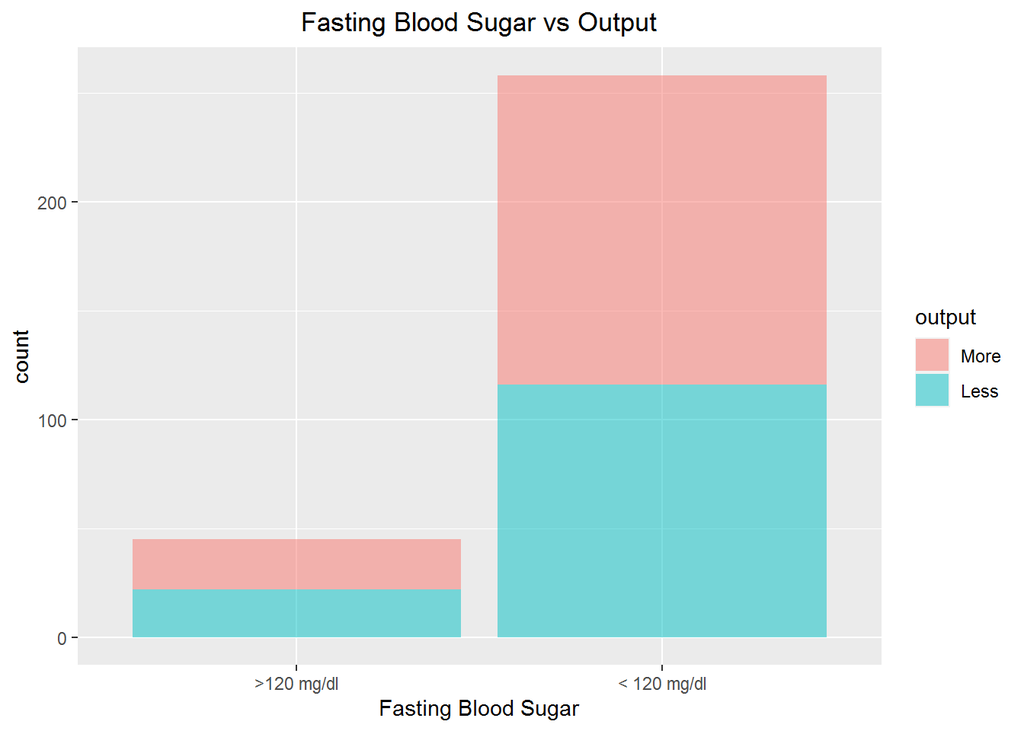

```r
plotting1(heart_df$fbs, "Fasting Blood Sugar")
```

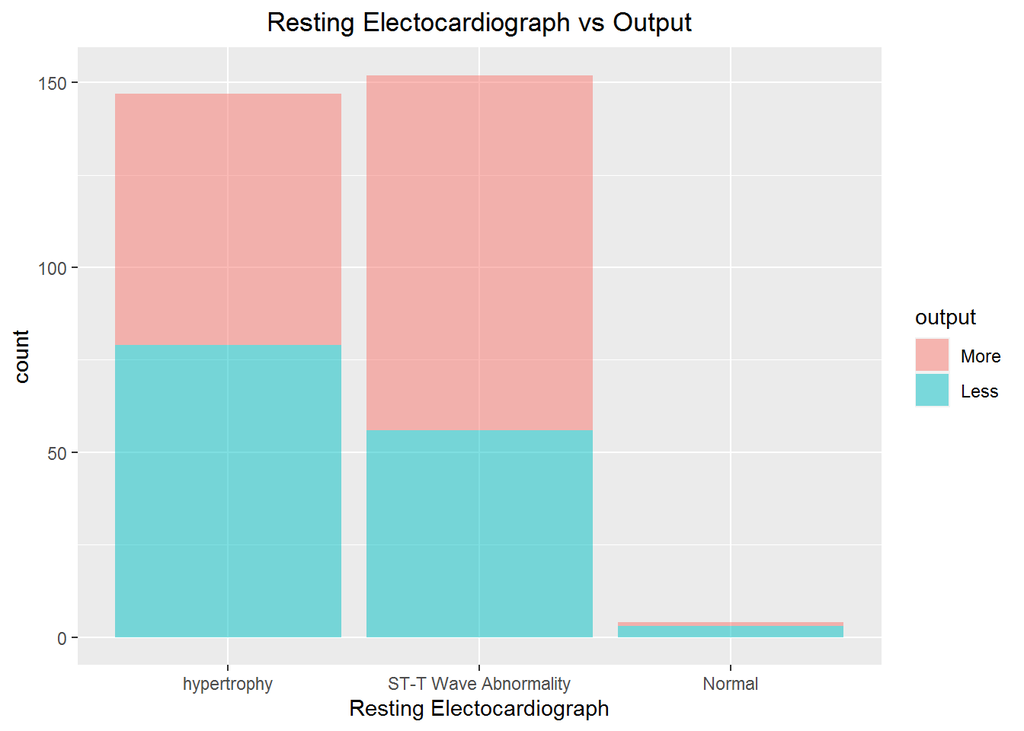

```r
plotting1(heart_df$restecg, "Resting Electocardiograph")
```

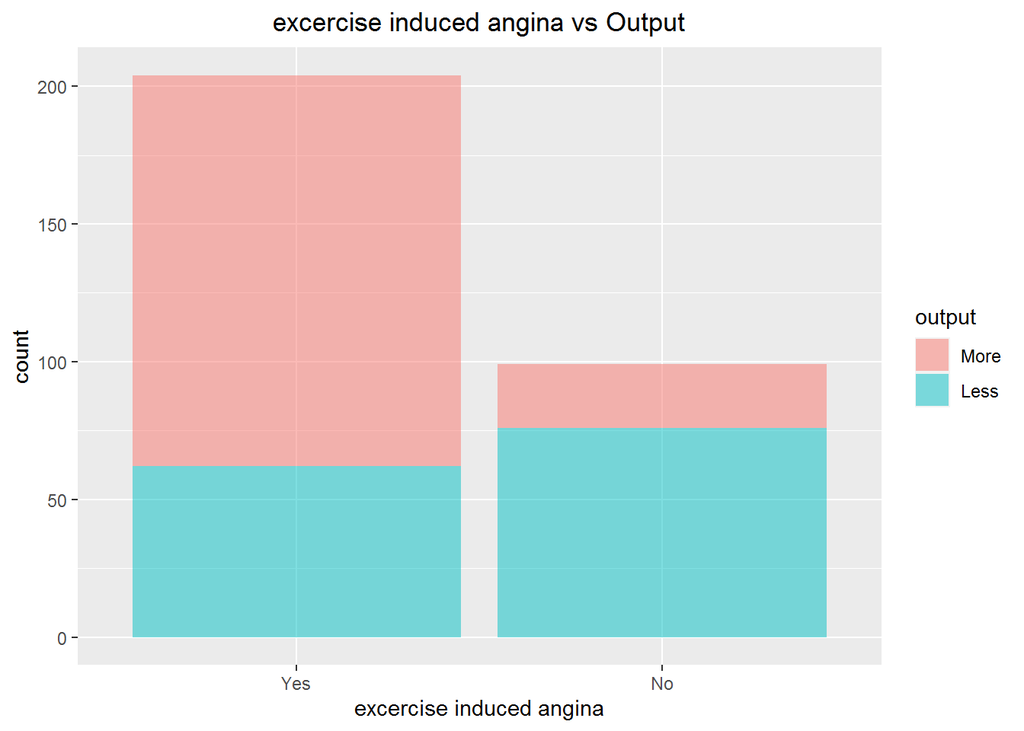

```r
plotting1(heart_df$exng, "excercise induced angina")
```

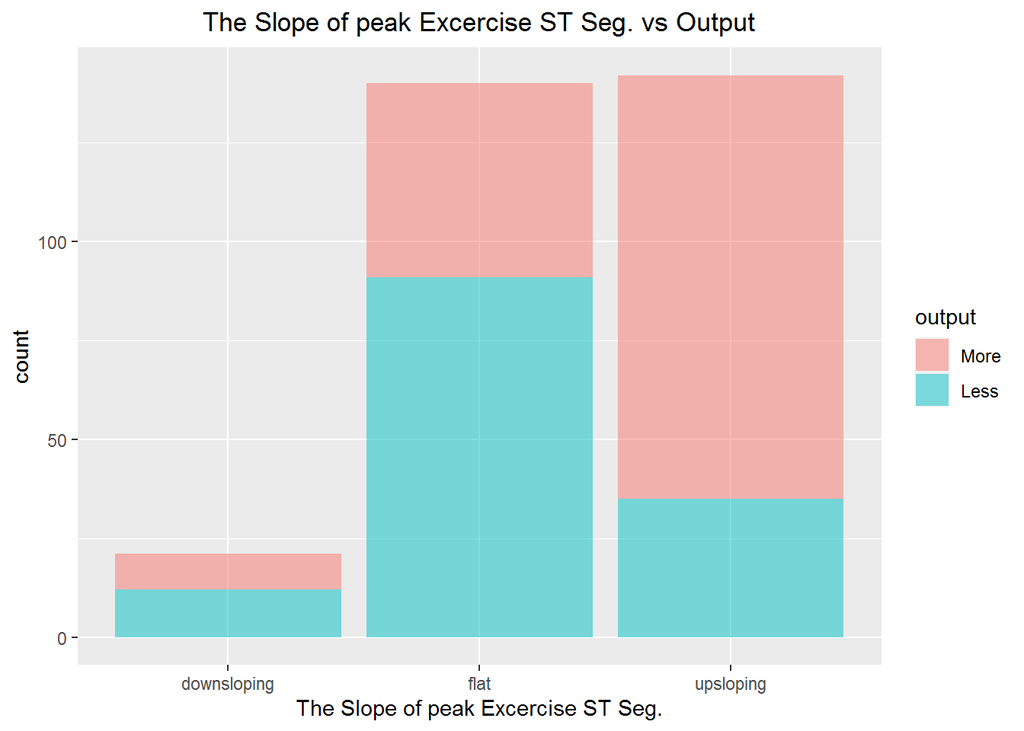

```r
plotting1(heart_df$slp, "The Slope of peak Excercise ST Seg.")
```

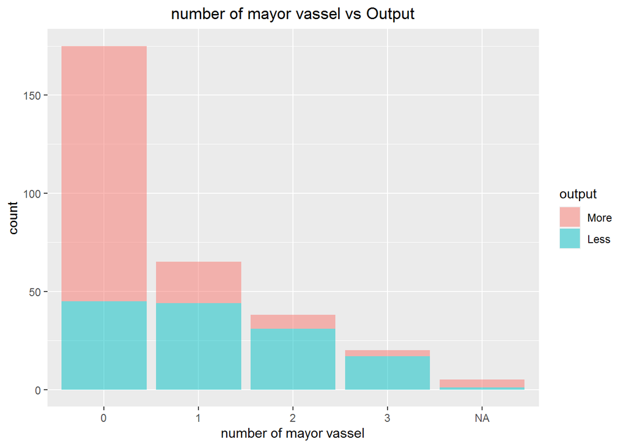

```r
plotting1(heart_df$caa, "number of mayor vassel")
```

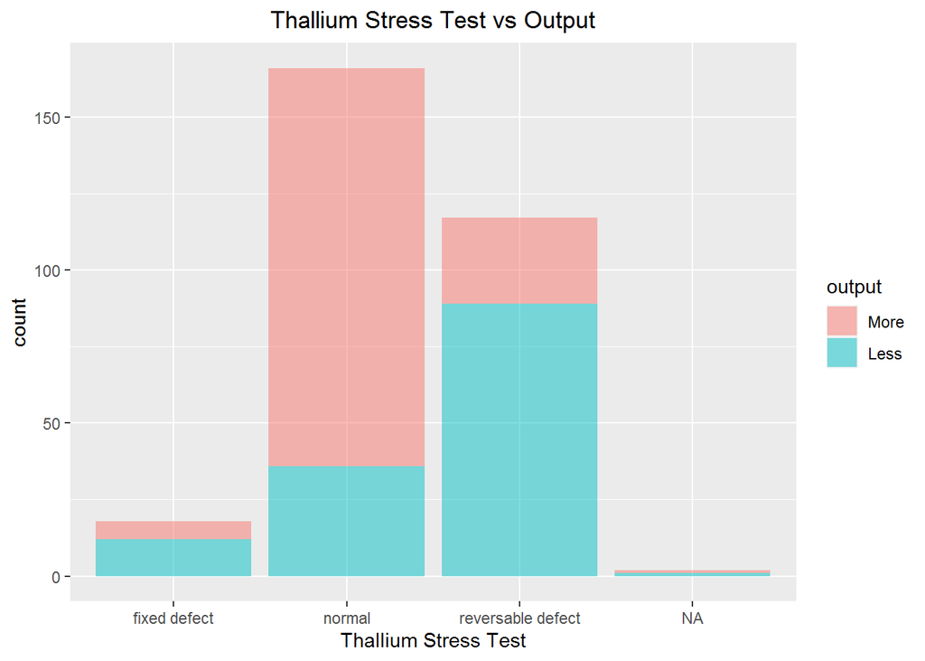

```r
plotting1(heart_df$thall, "Thallium Stress Test")
```

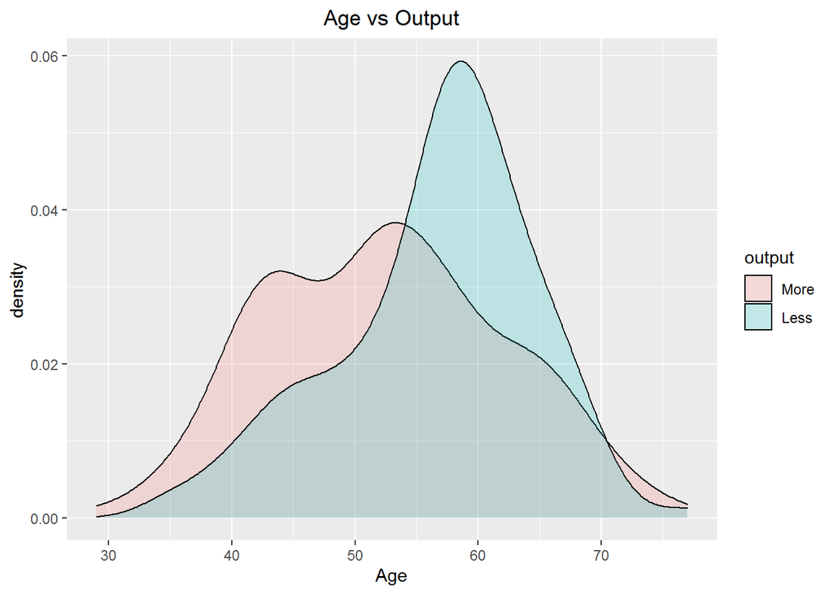

```r
# Integer Variable
plotting2 = function(x_column, label){
  ggplot(heart_df, aes(x = x_column, fill=output))+
    geom_density(alpha=0.2)+
    labs(title = paste(label, "vs Output"),
         x = label)+
    theme (plot.title = element_text(hjust = 0.5))
}

plotting2(heart_df$age, "Age")
```

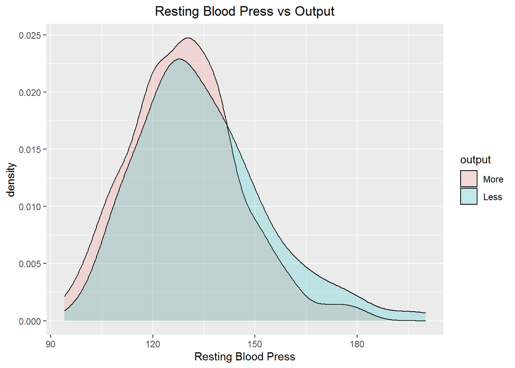

```r
plotting2(heart_df$trtbps, "Resting Blood Press")
```

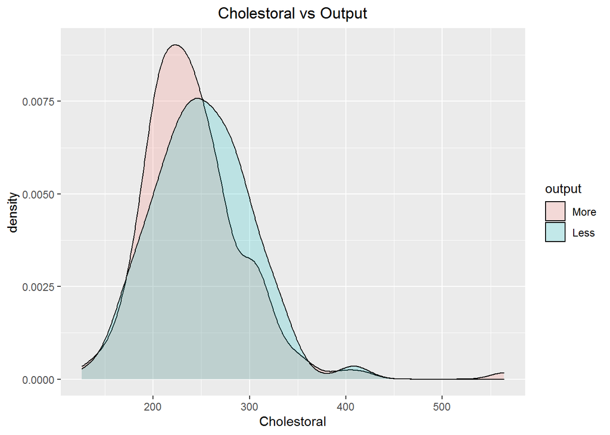

```r
plotting2(heart_df$chol, "Cholestoral")
```

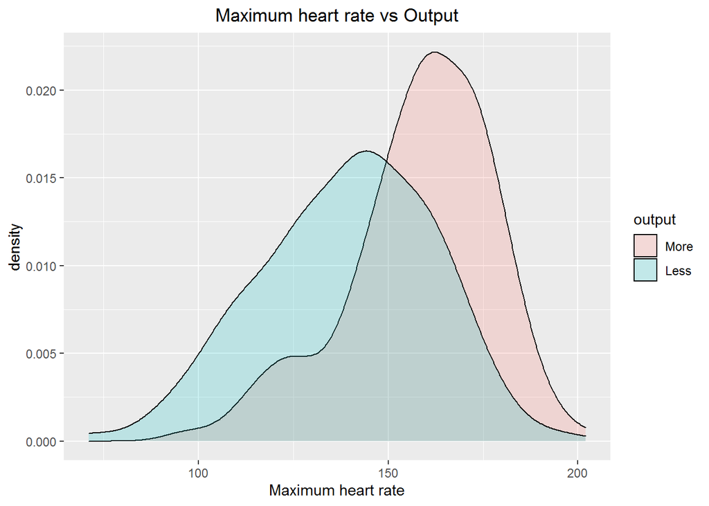

```r
plotting2(heart_df$thalachh, "Maximum heart rate")
```

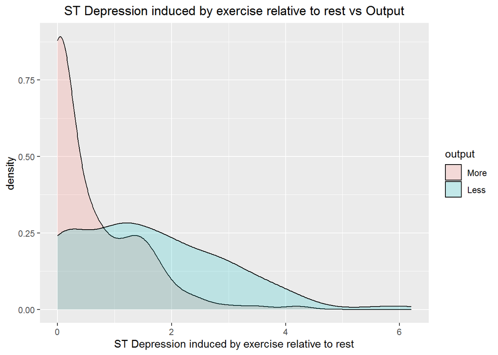

```r
plotting2(heart_df$oldpeak, "ST Depression induced by exercise relative to rest")
```

# 2.3. Multivariate Analysis

This part is making Multivariate.

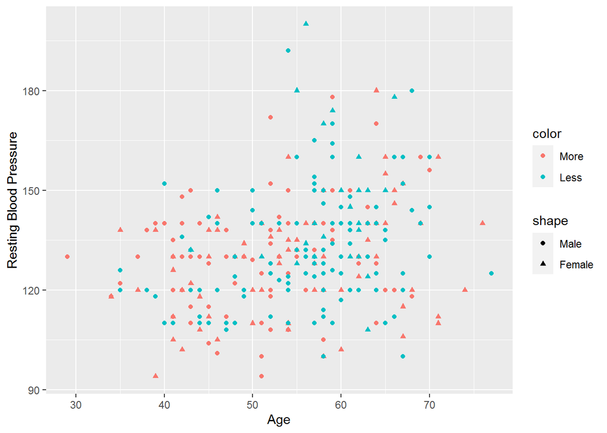

```r
plottingpoint = function(x_axis,label_x, y_axis,label_y, shape, color){
  ggplot(data = heart_df, aes (x = x_axis,
                               y= y_axis,
                               shape = shape,
                               color = color))+
    geom_point()+
    labs(x = label_x,
         y = label_y)
}

plottingpoint(heart_df$age, "Age", heart_df$trtbps, "Resting Blood Pressure", heart_df$sex, heart_df$output)
```

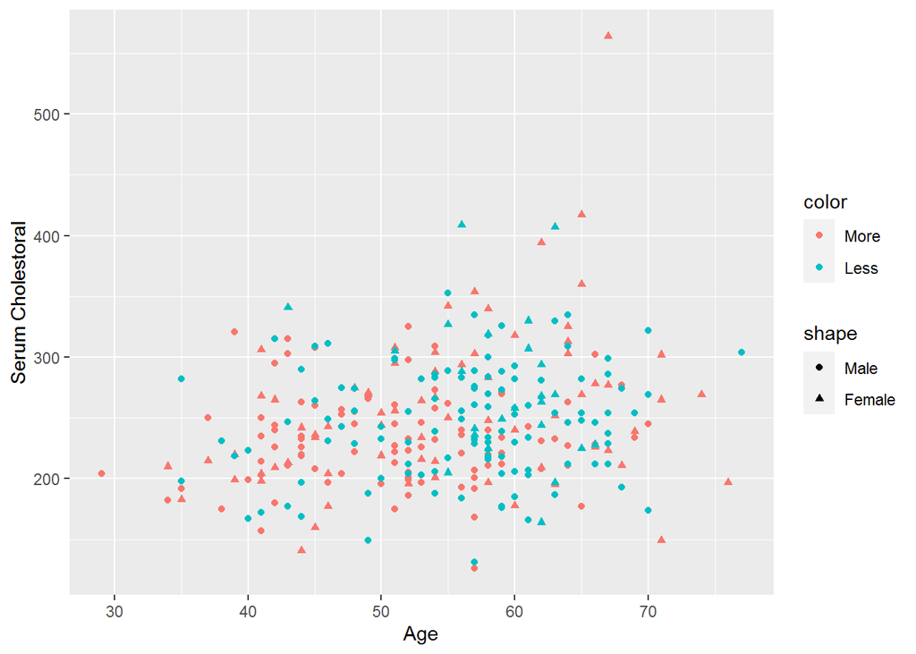

```r
plottingpoint(heart_df$age, "Age", heart_df$chol, "Serum Cholestoral", heart_df$sex, heart_df$output)
```

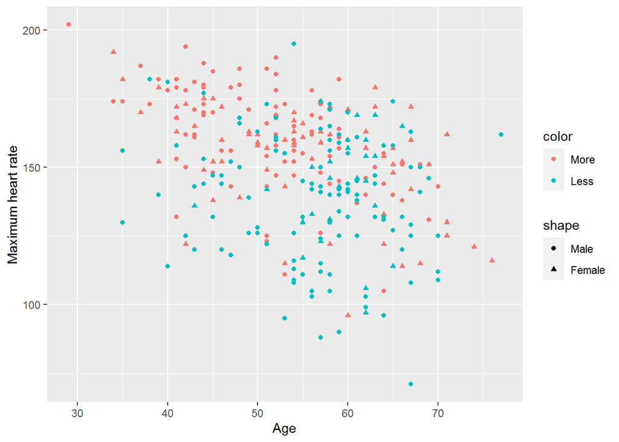

```r
plottingpoint(heart_df$age, "Age", heart_df$thalachh, "Maximum heart rate", heart_df$sex, heart_df$output)
```